# Exploring the 2016 Election data

Ben Marwick, Di Cook, Heike Hofmann, Rob Hyndman,Carson Sievert, Nicholas Tierney, Fang Zhou

2017-05-24

# Introduction

`eechidna` (Electoral Commission Handling Intelligent Data Nationally for Australia) is an R package that makes it easy to look at the data from the 2011 Australian Census, and the 2016 Federal Election.

This vignette documents how to access the data from the 2016 Federal Election (House of Representatives (first preferences and two party preferred). We obtained these data from http://results.aec.gov.au/ . This package incorporates data that is copyright Commonwealth of Australia (Australian Electoral Commission) 2016.

In this vignette we show a few typical methods to explore the data, inspired by [Peter Ellis’s](https://github.com/ellisp/) work on NZ election data.

# 2016 Federal Election House of Representatives data

In the `eechidna` package we have four election datasets, summarised here:

| Data object name | Description |
| --- | --- |
| aec2016_fp | first preference votes for candidates at each polling place |
| aec2016_fp_electorate | first preference votes for candidates at each electorate |
| aec2016_2pp | two party preferred votes for candidates at each polling place |
| aec2016_2pp_electorate | two party preferred votes for candidates at each electorate |

We can access and explore each of these using common methods in R, for example:

```r
library(eechidna)
library(plyr)
library(dplyr)
library(purrr)
library(knitr)
library(broom)
library(tidyr)
# inspect the data frame
glimpse(aec2016_fp)
```

```
## Observations: 64,029
## Variables: 26
## $ ID                 <int> 101, 101, 101, 101, 101, 101, 101, 101, 101...
## $ Electorate         <chr> "Canberra", "Canberra", "Canberra", "Canber...
## $ PollingPlaceID     <int> 8829, 8829, 8829, 8829, 8829, 64583, 64583,...
## $ PollingPlace       <chr> "Barton", "Barton", "Barton", "Barton", "Ba...
## $ CandidateID        <int> 28189, 28336, 29373, 28989, 999, 28189, 283...
## $ Surname            <chr> "BRODTMANN", "CAHILL", "BUCKNELL", "ADELAN-...
## $ GivenNm            <chr> "Gai", "Patricia", "Christopher D'Arcy", "J...
## $ BallotPosition     <int> 1, 2, 3, 4, 999, 1, 2, 3, 4, 999, 1, 2, 3, ...
## $ Elected            <chr> "Y", "N", "N", "N", "N", "Y", "N", "N", "N"...
## $ HistoricElected    <chr> "Y", "N", "N", "N", "N", "Y", "N", "N", "N"...
## $ PartyAb            <chr> "ALP", "GRN", "BTA", "LP", NA, "ALP", "GRN"...
## $ PartyNm            <chr> "Australian Labor Party", "The Greens", "Bu...
## $ OrdinaryVotes      <int> 777, 467, 81, 907, 45, 485, 177, 63, 394, 2...
## $ Swing              <dbl> -4.43, 4.24, -0.71, 4.01, -1.31, 4.17, 0.15...
## $ State              <chr> "ACT", "ACT", "ACT", "ACT", "ACT", "ACT", "...
## $ PollingPlaceTypeID <int> 1, 1, 1, 1, 1, 5, 5, 5, 5, 5, 5, 5, 5, 5, 5...
## $ PollingPlaceNm     <chr> "Barton", "Barton", "Barton", "Barton", "Ba...
## $ PremisesNm         <chr> "Telopea Park School", "Telopea Park School...
## $ PremisesAddress1   <chr> "New South Wales Cres", "New South Wales Cr...
## $ PremisesAddress2   <chr> NA, NA, NA, NA, NA, NA, NA, NA, NA, NA, NA,...
## $ PremisesAddress3   <chr> NA, NA, NA, NA, NA, NA, NA, NA, NA, NA, NA,...
## $ PremisesSuburb     <chr> "BARTON", "BARTON", "BARTON", "BARTON", "BA...
## $ PremisesStateAb    <chr> "ACT", "ACT", "ACT", "ACT", "ACT", "ACT", "...
## $ PremisesPostCode   <int> 2600, 2600, 2600, 2600, 2600, 2900, 2900, 2...
## $ Latitude           <dbl> -35.31510, -35.31510, -35.31510, -35.31510,...
## $ Longitude          <dbl> 149.1350, 149.1350, 149.1350, 149.1350, 149...
```

```r
# show the first few rows
head(aec2016_fp) %>% kable
```

| ID | Electorate | PollingPlaceID | PollingPlace | CandidateID | Surname | GivenNm | BallotPosition | Elected | HistoricElected | PartyAb | PartyNm | OrdinaryVotes | Swing | State | PollingPlaceTypeID | PollingPlaceNm | PremisesNm | PremisesAddress1 | PremisesAddress2 | PremisesAddress3 | PremisesSuburb | PremisesStateAb | PremisesPostCode | Latitude | Longitude |
| --- | --- | --- | --- | --- | --- | --- | --- | --- | --- | --- | --- | --- | --- | --- | --- | --- | --- | --- | --- | --- | --- | --- | --- | --- | --- |
| 101 | Canberra | 8829 | Barton | 28189 | BRODTMANN | Gai | 1 | Y | Y | ALP | Australian Labor Party | 777 | -4.43 | ACT | 1 | Barton | Telopea Park School | New South Wales Cres | NA | NA | BARTON | ACT | 2600 | -35.3151 | 149.1350 |
| 101 | Canberra | 8829 | Barton | 28336 | CAHILL | Patricia | 2 | N | N | GRN | The Greens | 467 | 4.24 | ACT | 1 | Barton | Telopea Park School | New South Wales Cres | NA | NA | BARTON | ACT | 2600 | -35.3151 | 149.1350 |
| 101 | Canberra | 8829 | Barton | 29373 | BUCKNELL | Christopher D’Arcy | 3 | N | N | BTA | Bullet Train For Australia | 81 | -0.71 | ACT | 1 | Barton | Telopea Park School | New South Wales Cres | NA | NA | BARTON | ACT | 2600 | -35.3151 | 149.1350 |
| 101 | Canberra | 8829 | Barton | 28989 | ADELAN-LANGFORD | Jessica | 4 | N | N | LP | Liberal | 907 | 4.01 | ACT | 1 | Barton | Telopea Park School | New South Wales Cres | NA | NA | BARTON | ACT | 2600 | -35.3151 | 149.1350 |
| 101 | Canberra | 8829 | Barton | 999 | Informal | Informal | 999 | N | N | NA | Informal | 45 | -1.31 | ACT | 1 | Barton | Telopea Park School | New South Wales Cres | NA | NA | BARTON | ACT | 2600 | -35.3151 | 149.1350 |
| 101 | Canberra | 64583 | Belconnen CANBERRA PPVC | 28189 | BRODTMANN | Gai | 1 | Y | Y | ALP | Australian Labor Party | 485 | 4.17 | ACT | 5 | Belconnen CANBERRA PPVC | Belconnen Community Centre | 26 Chandler St | NA | NA | BELCONNEN | ACT | 2900 | -35.2389 | 149.0701 |

We can see that the data contains 64,029 rows and 26 columns. Each of the four data objects can be accessed and inspected in this way. Note that some parties have slightly different names in different states. For example there is ‘The Nationals’ and the ‘National Party’. We’ve simplified the data by renaming some of the parties to the varient of the name that won the most votes.

# Which party won the election?

We can summarise the data to discover some basic details about the election. Let’s start by reproducing the overall result of the election by finding out which party won the most electorates according to the two party preferred votes:

```r
who_won <- aec2016_2pp_electorate %>%
  group_by(PartyNm) %>%
  tally() %>%
  arrange(desc(n))

# inspect
who_won %>%
  kable()
```

| PartyNm | n |
| --- | --- |
| Australian Labor Party | 69 |
| Liberal | 66 |
| The Nationals | 10 |
| Independent | 2 |
| Katter’s Australian Party | 1 |
| Nick Xenophon Team | 1 |
| The Greens | 1 |

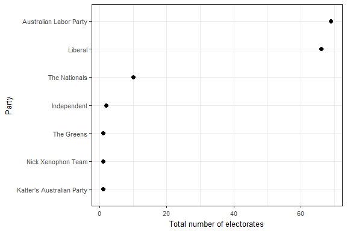

```r
# plot
library(ggplot2)
library(scales)
ggplot(who_won,
       aes(reorder(PartyNm, n),
           n)) +
  geom_point(size = 2) +
  coord_flip() +
  scale_y_continuous(labels = comma) +
  theme_bw() +
  ylab("Total number of electorates") +
  xlab("Party") +
  theme(text = element_text(size=10))
```

# Which party received the most ordinary votes?

An alternative way to evaluate the outcome of the election is by counting the number of ordinary first preference votes for each party (not including postal votes, preference flows, etc.). Here we can find the total number of ordinary votes for each party:

```r
total_votes_for_parties <- aec2016_fp %>%
  select(PartyNm, OrdinaryVotes) %>%
  group_by(PartyNm) %>%
  summarise(total_votes = sum(OrdinaryVotes, rm.na = TRUE)) %>%
  ungroup() %>%
  arrange(desc(total_votes))

#  inspect
total_votes_for_parties %>%
  head %>% # just the first 10 rows
  kable
```

| PartyNm | total_votes |
| --- | --- |
| Liberal | 4125368 |
| Australian Labor Party | 3955336 |
| The Greens | 1109641 |
| Informal | 636016 |
| The Nationals | 551648 |
| Independent | 319901 |

The table above shows a similar result, with the Liberal Party recieving the most ordinary votes.

We can plot the ordinary vote count like so:

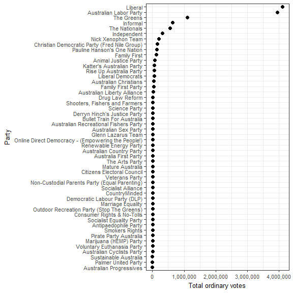

```r
ggplot(total_votes_for_parties,
       aes(reorder(PartyNm, total_votes),
           total_votes)) +
  geom_point(size = 2) +
  coord_flip() +
  scale_y_continuous(labels = comma) +
  theme_bw() +
  ylab("Total ordinary votes") +
  xlab("Party") +
  theme(text = element_text(size=10))
```

# Which candidate did the best?

There are a few ways we can answer this question. We can see who received the highest number of ordinary votes, like this:

```r
who_most_votes <-
aec2016_fp %>%
  filter(CandidateID != 999) %>% #exclude informal votes
  mutate(candidate_full_name = paste0(GivenNm, " ", Surname, " (", CandidateID, ")")) %>%
  group_by(candidate_full_name) %>%
  summarise(total_votes_for_candidate = sum(OrdinaryVotes, rm.na = TRUE)) %>%
  arrange(desc(total_votes_for_candidate))
# inspect
who_most_votes %>%
  mutate(total_votes_for_candidate =
           prettyNum(total_votes_for_candidate,
                     big.mark = ","))  %>%
  head %>%
  kable
```

| candidate_full_name | total_votes_for_candidate |
| --- | --- |
| Andrew Keith LEIGH (28190) | 50,877 |
| Brendan O’CONNOR (28274) | 50,618 |
| Michael McCORMACK (29304) | 50,458 |
| Andrew BROAD (28415) | 49,603 |
| Gai BRODTMANN (28189) | 49,383 |
| Sussan LEY (28699) | 48,016 |

But this is a crude measure of how successful a candidate was in the election, because electorates with more people will result in more votes for the winner, even if the victory is only by a tiny margin. So let’s see remove the effect of the population size in the electorates by finding out who won the highest proportion of votes in their electorate.

```r
who_most_votes_prop <-
aec2016_fp %>%
  filter(CandidateID != 999) %>% #exclude informal votes
  mutate(candidate_full_name =
           paste0(GivenNm, " ", Surname, " (", CandidateID, ")")) %>%
  group_by(Electorate, candidate_full_name) %>%
  summarise(sum_votes = sum(OrdinaryVotes))  %>%
  mutate(prop_votes = round(sum_votes / sum(sum_votes), 3),
         sum_votes = prettyNum(sum_votes, ",")) %>%
  ungroup %>%
  arrange(desc(prop_votes))

# inspect
who_most_votes_prop %>%
  data.frame %>%
  head %>%
  kable
```

| Electorate | candidate_full_name | sum_votes | prop_votes |
| --- | --- | --- | --- |
| Curtin | Julie BISHOP (28746) | 44,066 | 0.660 |
| Blaxland | Jason CLARE (28931) | 43,926 | 0.647 |
| Mallee | Andrew BROAD (28415) | 49,602 | 0.645 |
| Gorton | Brendan O’CONNOR (28274) | 50,617 | 0.629 |
| Chifley | Ed HUSIC (28890) | 46,173 | 0.621 |
| Fowler | Chris HAYES (28945) | 45,709 | 0.620 |

## Which candidate won with the smallest number of votes?

```r
who_won_least_votes_prop <-
 aec2016_fp %>%
   filter(CandidateID != 999) %>% # keep only the winners
   mutate(candidate_full_name =
            paste0(GivenNm, " ", Surname, " (", CandidateID, ")")) %>%
   group_by(Electorate, candidate_full_name) %>%
   summarise(sum_votes = sum(OrdinaryVotes)) %>%
   mutate(prop_votes = round(sum_votes / sum(sum_votes), 2)) %>%
   ungroup %>%
   left_join(aec2016_2pp_electorate %>%
               mutate(candidate_full_name =
            paste0(GivenNm, " ", Surname, " (", CandidateID, ")")), "candidate_full_name") %>%
   filter(Elected == "Y") %>%
   select(Electorate.x,
          candidate_full_name,
          prop_votes,
          PartyNm) %>%
   arrange(prop_votes)

# have a look
who_won_least_votes_prop %>%
 head %>%
 kable
```

| Electorate.x | candidate_full_name | prop_votes | PartyNm |
| --- | --- | --- | --- |
| Melbourne Ports | Michael DANBY (28267) | 0.27 | Australian Labor Party |
| Herbert | Cathy O’TOOLE (28997) | 0.31 | Australian Labor Party |
| Richmond | Justine ELLIOT (28987) | 0.31 | Australian Labor Party |
| Griffith | Terri BUTLER (28921) | 0.34 | Australian Labor Party |
| Hindmarsh | Steve GEORGANAS (29071) | 0.34 | Australian Labor Party |
| Flynn | Ken O’DOWD (28049) | 0.35 | Liberal |

```r
fairfax <-
aec2016_fp %>%
  filter(CandidateID != 999) %>% # exclude informal votes
  filter(Electorate == "Fairfax") %>%
  mutate(candidate_full_name =
           paste0(GivenNm, " ",
                  Surname,
                  " (",
                  CandidateID,
                  ")")) %>%
  group_by(Electorate, candidate_full_name) %>%
  summarise(sum_votes = sum(OrdinaryVotes)) %>%
  mutate(prop_votes = round(sum_votes / sum(sum_votes), 2),
         sum_votes = prettyNum(sum_votes, big.mark = ",")) %>%
  ungroup %>%
  arrange(desc(prop_votes))

# inspect
fairfax %>%
  head %>%
  kable
```

| Electorate | candidate_full_name | sum_votes | prop_votes |
| --- | --- | --- | --- |
| Fairfax | Ted O’BRIEN (28035) | 37,446 | 0.49 |
| Fairfax | Scott ANDERSON (29021) | 15,903 | 0.21 |
| Fairfax | Susan ETHERIDGE (29230) | 9,508 | 0.12 |
| Fairfax | Robert PASQUALI (29233) | 7,425 | 0.10 |
| Fairfax | David REES (29227) | 1,964 | 0.03 |
| Fairfax | Keith Alexander CAMPBELL (27972) | 2,517 | 0.03 |

# How did each electorate vote in each state?

We can look at the proportion of voters for a particular party in each electorate, grouped by each state. This plot was inspired by Peter Ellis’s work on the NZ election data.

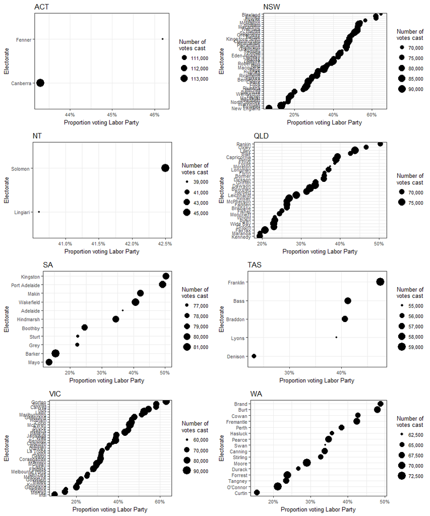

```r
# summarise and compute proportion of votes for a particular party
p <- aec2016_fp %>%
    filter(CandidateID != 999) %>% # exclude informal votes
  group_by(Electorate, State) %>%
  summarise(
    TotalVotes = sum(OrdinaryVotes),
    ProportionLabor = round(sum(OrdinaryVotes[PartyNm == "Australian Labor Party"]) / TotalVotes, 3)) %>%
  filter(TotalVotes != 0) %>%
  arrange(desc(ProportionLabor)) %>%
  group_by(State) %>%
  # send the data to the plotting function
  do(plots=ggplot(data = .) +
       aes(x = ProportionLabor,
           y = reorder(Electorate, ProportionLabor),
           size = TotalVotes,
           label = State) +
       geom_point() +
       ylab("Electorate") +
       labs(title = .$State) +
       scale_x_continuous("Proportion voting Labor Party",
                          label = percent) +
       scale_size("Number of\nvotes cast",
                  label = comma)  +
       theme_bw() +
       theme(text = element_text(size=10)))

# draw the plots
library(gridExtra)
n <- length(p$plots)
nCol <- floor(sqrt(n))
do.call("grid.arrange", c(p$plots, ncol=nCol))
```

# How are party votes correlated?

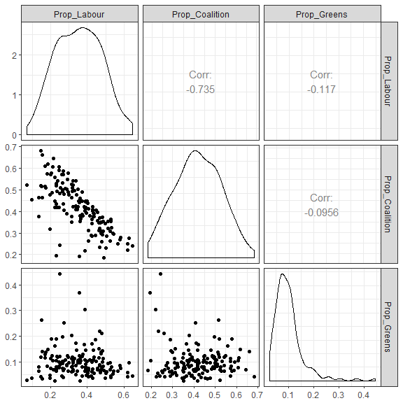

```r
# Comparing party and candidate votes of several parties -------
proportions <- aec2016_fp %>%
  filter(CandidateID != 999) %>% # exclude informal votes
  group_by(Electorate) %>%
  summarise(Prop_Labour = sum(OrdinaryVotes[PartyNm == "Australian Labor Party"]) / sum(OrdinaryVotes),
            Prop_Coalition = sum(
              OrdinaryVotes[PartyNm == "Liberal"],
              OrdinaryVotes[PartyNm == " Country Liberal Party"],
              OrdinaryVotes[PartyNm == "The Nationals"],
              OrdinaryVotes[PartyNm == "Country Liberals (NT)"]
              ) / sum(OrdinaryVotes),
            Prop_Greens = sum(OrdinaryVotes[PartyNm == "The Greens"]) / sum(OrdinaryVotes))

# make a scatterplot matrix
library(GGally)
ggpairs(proportions, columns = 2:ncol(proportions)) + theme_bw()
```

# How do election results correlate with census data?

One of our motivations for creating this package was to make it easy to explore relationships between political views and socio-economic conditions across Australia. With a few simple R functions, we can join the census data to the election data and build models to explore relationships.

Here’s how we join the two datasets together, the common variable is the Electorate:

```r
census_and_election <- left_join(aec2016_2pp_electorate,
                                 abs2011,
                                 by = c("Electorate" = "Electorate"))
```

Now we can easily explore some relationships between the census data and the two party preferring voting patterns. For example, what census variable mostly strongly correlates with the percentage that vote Labor? The first step in these kinds of explorations is always to visualise the data:

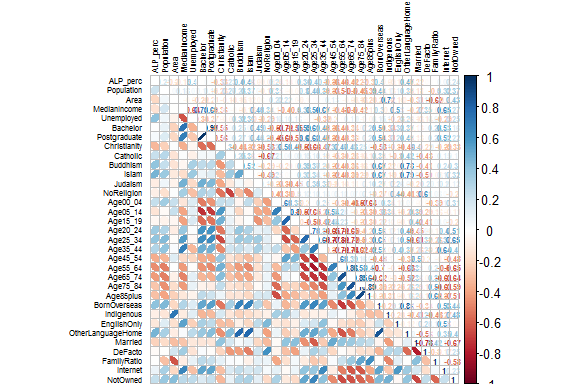

```r
# subset only the columns we want for the model
census_and_election_subset <-
  census_and_election %>%
  ungroup %>%
  select(Electorate,
         Average_Australian_Labor_Party_Percentage_in_electorate,
         Population:NotOwned)  %>%
  rename(ALP_perc = Average_Australian_Labor_Party_Percentage_in_electorate)

library(corrplot)
M <- cor(census_and_election_subset[, c(2:ncol(census_and_election_subset))],
         use = "pairwise.complete.obs")
corrplot.mixed(M,
               lower="ellipse",
               upper="number",
               tl.pos = "lt",
               tl.cex = 0.5,
               tl.col = "black",
               number.cex= 0.5)
```

It’s a little hard to read because we have so many variables. But we can spot some potentially interesting correlations, as well as some obvious ones.

The table below gives an overall summary of the model containing all the census variables. We see that the p-value is very low, indicating that we have some interactions that are probably not due to chance alone.

```r
options(scipen = 10) # for more readable numbers
census_variables <- names(abs2011)[-c(1:3)]

# compute the multiple regressions
mutliple_regression_model <-
  census_and_election %>%
  ungroup %>%
  select(
         Average_Australian_Labor_Party_Percentage_in_electorate,
         Population:NotOwned) %>%
  lm(Average_Australian_Labor_Party_Percentage_in_electorate ~ .,
     data = . )

mutliple_regression_model %>%
  glance %>%
  dmap(round, 3) %>%
  kable
```

| r.squared | adj.r.squared | sigma | statistic | p.value | df | logLik | AIC | BIC | deviance | df.residual |
| --- | --- | --- | --- | --- | --- | --- | --- | --- | --- | --- |
| 0.709 | 0.626 | 7.109 | 8.544 | 0 | 33 | -471.412 | 1010.824 | 1112.032 | 5659.484 | 112 |

The table below shows the variables that have a significant effect on the percentage of Labor votes across all electorates:

```r
# find the variables with a significant effect
mutliple_regression_model %>%
  tidy %>%
  filter(p.value < 0.05) %>%
  dmap_if(is.numeric, round, 3) %>%
  arrange(p.value) %>%
  kable
```

| term | estimate | std.error | statistic | p.value |
| --- | --- | --- | --- | --- |
| Unemployed | 4.063 | 1.140 | 3.565 | 0.001 |
| NotOwned | -2.611 | 0.777 | -3.362 | 0.001 |
| Internet | 3.390 | 1.132 | 2.995 | 0.003 |
| EnglishOnly | -0.777 | 0.263 | -2.958 | 0.004 |
| Population | 0.000 | 0.000 | -2.251 | 0.026 |

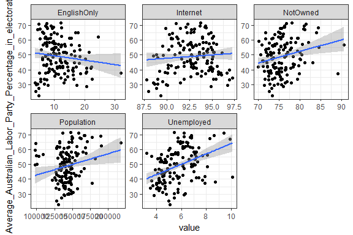

```r
# model that includes all census variables
all_vars <- mutliple_regression_model %>%
  tidy %>%
  filter(p.value < 0.05) %>%
  arrange(p.value)

census_and_election %>%
  ungroup %>%
  select_(.dots = all_vars$term,
          "Average_Australian_Labor_Party_Percentage_in_electorate")  %>%
  gather(variable,
         value,
         -Average_Australian_Labor_Party_Percentage_in_electorate) %>%
  ggplot(aes(value, Average_Australian_Labor_Party_Percentage_in_electorate)) +
  geom_point() +
  geom_smooth(method = "lm") +
  facet_wrap( ~ variable, scales = "free") +
  theme_bw()
```

# Senate results

A quick look at the senate results for 2016, using barchart by overall composition of the senate, and by state.

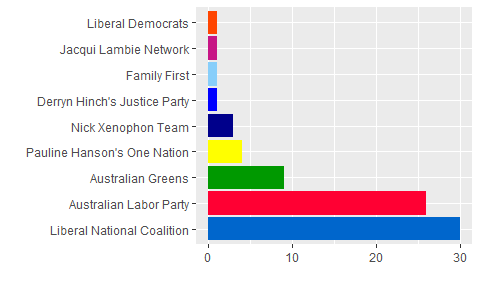

```r
library(readr)
senate <- read_csv("http://results.aec.gov.au/20499/Website/Downloads/SenateSenatorsElectedDownload-20499.csv",
    skip = 1)

coalition <- c("Country Liberals (NT)", "Liberal", "Liberal National Party of Queensland",
    "The Nationals")

labor <- c("Australian Labor Party", "Australian Labor Party (Northern Territory) Branch",
    "Labor")

greens <- c("The Greens", "Australian Greens", "The Greens (WA)")

senate <- senate %>% mutate(PartyNm = ifelse(as.character(PartyNm) %in% coalition,
    "Liberal National Coalition", PartyNm))

senate <- senate %>% mutate(PartyNm = ifelse(as.character(PartyNm) %in% labor,
    "Australian Labor Party", PartyNm))

senate <- senate %>% mutate(PartyNm = ifelse(as.character(PartyNm) %in% greens,
    "Australian Greens", PartyNm))

senate$PartyNm <- factor(senate$PartyNm, levels = names(sort(table(senate$PartyNm),
    decreasing = T)))

# Order = Liberal National Coalition, Australian Labor Party, The Greens,
# Palmer, motoring, sports, family first, Lib Dems, Nick Xenophon
partycolours = c("#0066CC", "#FF0033", "#009900", "#FFFF00", "#00008B", "#0000FF",
    "#87CEFA", "#C71585", "#FF4500")

ggplot(data = senate, aes(x = PartyNm, fill = PartyNm)) + geom_bar() + xlab("") +
    ylab("") + scale_fill_manual(name = "Party", values = partycolours) + coord_flip() +
    theme(legend.position = "None")
```

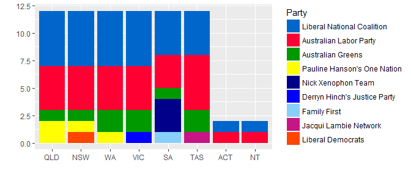

```r
senate$StateAb <- factor(senate$StateAb, levels = c("QLD", "NSW", "WA", "VIC",
    "SA", "TAS", "ACT", "NT"))

ggplot(data = senate, aes(x = StateAb, fill = PartyNm)) + geom_bar() + xlab("") +
    ylab("") + scale_fill_manual(name = "Party", values = partycolours)
```